# Meeting 8 - Parameter Estimation and Hypothesis Testing

Matthew E. Aiello-Lammens

# Refresh

What is a statistical distribution?

What are some of the distributions we talked about in the past?

What characteristics of distributions are we often interested in?

# Other important distributions in data analysis

- Standard Normal
- Student’s $t$ distribution
- $\chi^2$ distribution
- $F$ distribution

## Standard Normal distribution

Recall that in [Lecture 6](http://mlammens.github.io/ENS-623-Research-Stats/lectures/Lecture-6.html#normal-distribution) we were introduced to the Normal (or Gaussian) Distribution with pdf:

$$f(x|\mu,\sigma) \thicksim \frac{1}{\sqrt{2\pi\sigma^2}} e^{-\frac{(x-\mu)^2}{2\sigma^2}}$$

The **Standard Normal** distribution is a **Normal** distribution with $\mu = 0$ and $\sigma = 1$.

#### Challenge

Draw 1000 samples from the standard normal distribution and plot a histogram and density curve for the resulting data. After making this plot, try 10,000 samples.

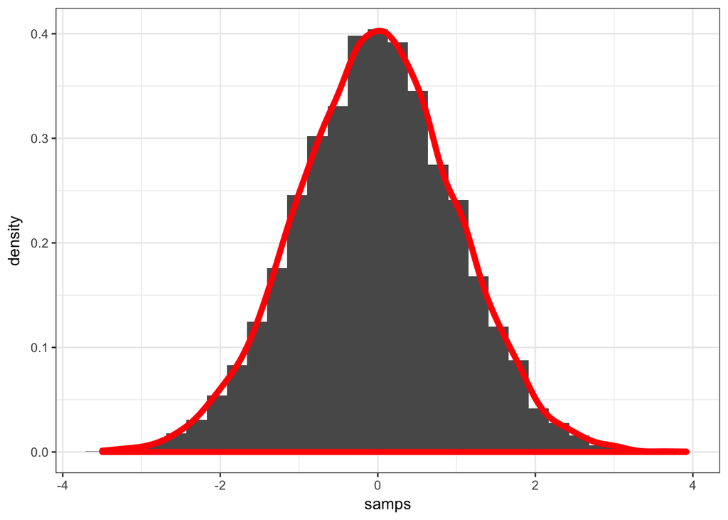

```r
stdnorm_samps <- data.frame( samps = rnorm(n = 10000, mean = 0, sd = 1) )

library(ggplot2)

ggplot(data = stdnorm_samps, aes(x = samps)) +
  geom_histogram( aes( y = ..density.. ) ) +
  geom_density(colour = "red", size = 2) +
  theme_bw()
```

- How well does the density plot represent the standard normal distribution?
- Can we add the functional form of the normal distribution?

```r
ggplot(data = stdnorm_samps, aes(x = samps)) +
  geom_histogram( aes( y = ..density.. ) ) +
  geom_density(colour = "red", size = 2) +
  stat_function( fun = dnorm, colour = "blue", alpha = 0.6, size = 2) +
  theme_bw()
```

We can convert from a normal distribution with any mean $\mu$ and standard deviation $\sigma$ to the standard normal by subtracting the mean from each value, then dividing by the standard deviation:

$$z_i = \frac{y_i - \mu}{\sigma}$$

### The utility of knowing the amount of area under the curve for probability densities

- Where do 95% of the values from the standard normal fall? **Introducing `qnorm`.**

```r
qnorm(.025)
```

```
## [1] -1.959964
```

```r
qnorm(.975)
```

```
## [1] 1.959964
```

- How might we visualize this?

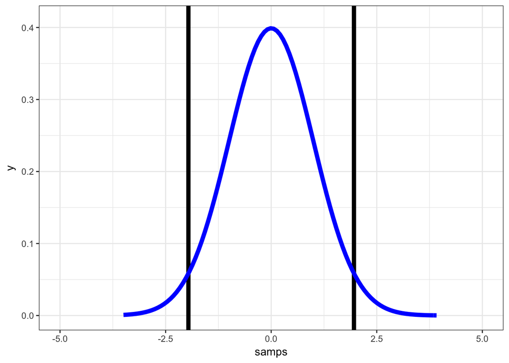

```r
ggplot(data = stdnorm_samps, aes(x = samps)) +
  coord_cartesian(xlim = c(-5, 5), ylim = c(0, 0.41)) +
  geom_vline(xintercept = c(-1.96, 1.96), size = 2 ) +
  stat_function( fun = dnorm, colour = "blue", size = 2) +
  theme_bw()
```

# The Central Limit Theorem

This section gets into more nitty-gritty probability and statistics. You should review this information in both of the course text books.

## Sampling distribution of the mean

The frequency distribution of the **mean values** of several samples taken from a population.

From Q&K p. 18:

> The probability distribution of means of samples from a normal distribution is also normally distributed.

#### Challenge

1. Take 100 samples of 10 observations from a normal distribution with a mean of 0 and a standard deviation of 1. Plot a histogram of the means.
2. Increase the number of samples. How does this affect the outcome?
3. Increase the number of observations. How does this affect the outcome?

## CLT

In the limit as $n \to \infty$, the probability distribution of means of samples from *any distribution* will approach a normal distribution.

#### Problem Set 6 - review

Plot a histogram of 100 observations that are **Poisson distributed** with a $\lambda$ value $= 1$. Describe the shape of the distribution. Does it look normal?

```r
ggplot(data = NULL) +
  geom_histogram(aes(x = rpois(100, lambda = 1)))
```

Next, take 100 samples of 10 observations from a **Poisson distribution**, calculate the mean for each sample. Plot a histogram of the means.

## Using the CLT

From Q&K p. 18:

> The expected value or mean of the probability distribution of sample means equals the mean of the population ($\mu$) from which the samples were taken.

### Standard error of the sample mean

We just demonstrated that **sample means are normally distributed**. What can we do with this? To start, we can say something about the precision and accuracy of our estimates of the *population* mean based on the *sample* mean.

**Standard error of the mean** - the expected value of the standard deviation of the sample mean:

$$\sigma_{\bar{y}} = \frac{\sigma}{\sqrt{n}}$$

Often times we only have **one sample** from the population. What can we say then?

Standard error of the mean:

$$s_{\bar{y}} = \frac{s}{\sqrt{n}}$$

where $s$ is the sample estimate of the standard deviation of the original population and $n$ is the sample size.

**NB:** The standard error of the means “tells us about the error in using $\bar{y}$ to estimate $\mu$.”

## Confidence intervals for the population mean

Recall that we can convert any observation from normal distribution to it’s equivalent value from a standard normal distribution using:

$$z_i = \frac{y_i - \mu}{\sigma}$$

These are sometimes called *z-scores*.

Using this formula, we can convert a sample mean, $\bar{y}$, into its corresponding value from a standard normal using:

$$z = \frac{\bar{y} - \mu}{\sigma_{\bar{y}}}$$

where the denominator is the standard error of the mean (see above).

We can use this information to estimate how confident we are that are sample mean is a good representation of the *true* population mean. Again, we are doing this by taking advantage of the fact that we know the sample means are *normally distributed*. We calculate the range in which 95% of the sample mean values fall.

In mathematical terms, this looks like:

$$P\{\bar{y} - 1.96\sigma_{\bar{y}} \leq \mu \leq \bar{y} + 1.96\sigma_{\bar{y}} \} = 0.95$$

**VERY IMPORTANT:** The probability statement here is about the *interval*, not $\mu$. $\mu$ is not a random variable; it is fixed. What we are saying is that there is 95% confidence that this interval includes the population mean, $\mu$.

### Unknown $\sigma$ (and $\sigma_{\bar{y}}$)

We rarely know $\sigma$, so we cannot calculate $\sigma_{\bar{y}}$. So what *can* we do?

Instead, we use the sample standard deviation, $s_{\bar{y}}$. So now we are dealing with a random variable that looks like:

$$\frac{\bar{y}-\mu}{s_{\bar{y}}}$$

which is no longer standard normal distributed, but rather *t* distributed.

#### Challenge

Use whatever resource available to you, and look-up the *t* distribution. What is/are the parameter(s) of the *t* distribution?

### Degrees of freedom

> The number of observations in our sample that are “free to vary” when we are estimating the variance (Q&K p.20; Box 2.1).

If I have calculated the mean, how many observations, out of a total of *n*, are free to vary?

**Answer:** $n-1$. Once I have the mean, I can use it and any $n-1$ values to calculate the *n*th value.

General rule regarding df’s:

> the df is the number of observations minus the number of parameters included in the formula for the variance (Q&K p.20; Box 2.1).

## Standard error of other statistics

> The standard error is … the standard deviation of the probability distribution of a specific statistics (Q&K p. 20).

### Standard error of the sample variance

The distribution of the sample variance is *not normal*. It is $\chi^2$ distributed.

Mathematically, this is explained as:

$$X \thicksim N(0,1) \to X^2 \thicksim \chi^2$$

Intuitively, why does this make sense?